# Discovering Iris Subtypes with MixClustVIjl

A step-by-step introduction to Bayesian mixture model clustering on the classic Iris dataset

Published

January 1, 2026

## 1 Introduction

The Iris dataset [@fisher1936use] contains 150 flower measurements across three species (*Iris setosa*, *Iris versicolor*, *Iris virginica*), with 50 observations per species. Four morphological features are measured for each flower: sepal length, sepal width, petal length, and petal width (all in cm).

This notebook uses `MixClustVIjl` to **cluster these 150 flowers without ever seeing the species labels** — treating the problem as a purely unsupervised task. We then compare the discovered clusters against the true species to validate the result. Along the way, every diagnostic and visualization function in the package is demonstrated.

**Note**

The point is not simply to recover three groups from a famous dataset. The point is to see what `MixClustVIjl` does automatically: it selects $K$ from scratch, decides which features actually drive the cluster structure, and produces interpretable subtype profiles — all from a single function call.

## 2 Setup

```julia
using MixClustVIjl
using CSV, DataFrames, Statistics, Random, Printf
```

```
Precompiling packages...
   5351.8 ms  ✓ MixClustVIjl
  1 dependency successfully precompiled in 6 seconds. 192 already precompiled.
```

## 3 Loading the Data

```julia
iris = CSV.read(joinpath(@__DIR__, "../data/iris.csv"), DataFrame)
println("Dimensions: ", size(iris))
first(iris, 5)
```

```
Dimensions: (150, 5)
```

5×5 DataFrame

| Row | sepal_length Float64 | sepal_width Float64 | petal_length Float64 | petal_width Float64 | species String15 |
| --- | --- | --- | --- | --- | --- |
| 1 | 5.1 | 3.5 | 1.4 | 0.2 | Iris-setosa |
| 2 | 4.9 | 3.0 | 1.4 | 0.2 | Iris-setosa |
| 3 | 4.7 | 3.2 | 1.3 | 0.2 | Iris-setosa |
| 4 | 4.6 | 3.1 | 1.5 | 0.2 | Iris-setosa |
| 5 | 5.0 | 3.6 | 1.4 | 0.2 | Iris-setosa |

The four continuous features will be standardized before fitting (zero mean, unit variance), as expected by Gaussian margins.

```julia
feature_names = ["sepal_length", "sepal_width", "petal_length", "petal_width"]

dataset = Vector{Any}(undef, 4)
for (j, col) in enumerate([:sepal_length, :sepal_width, :petal_length, :petal_width])
    v = Float64.(iris[!, col])
    dataset[j] = (v .- mean(v)) ./ std(v)
end

# True species labels (for validation only — never shown to the model)
species_map = Dict("Iris-setosa" => 1, "Iris-versicolor" => 2, "Iris-virginica" => 3)
labels_true = [species_map[s] for s in iris.species]

println("n = ", length(labels_true), ", K_true = ", length(unique(labels_true)))
```

```
n = 150, K_true = 3
```

## 4 Fitting the Model

We start with $K_{\text{fit}} = 8$ components (deliberately over-specified) and let the sparse Dirichlet prior plus post-hoc pruning select the true $K$ automatically.

### 4.1 SFRM — Shared Feature Relevance Model

Under `SFRM()`, each feature has a single relevance probability shared across all clusters: a feature is either relevant to the clustering or not, uniformly across all groups.

```julia
Random.seed!(42)
res_sfrm = mixClust(dataset, 8;
                    model_setting = SFRM(),
                    alpha_0  = 0.01,
                    max_iter = 2000,
                    tol      = 1e-5,
                    prune    = true,
                    n_init        = 10,
                    max_iter_init = 10)

K_sfrm = size(res_sfrm.w, 2)
@printf("SFRM → K̂ = %d clusters (converged in %d / 2000 iterations)\n",
        K_sfrm, length(res_sfrm.elbo_history))
```

```
SFRM → K̂ = 3 clusters (converged in 82 / 2000 iterations)
```

### 4.2 LFRM — Local Feature Relevance Model

Under `LFRM()`, each feature can be relevant in some clusters but not in others — allowing finer, subgroup-specific signal.

```julia
Random.seed!(42)
res_lfrm = mixClust(dataset, 8;
                    model_setting = LFRM(),
                    alpha_0  = 0.01,
                    max_iter = 2000,
                    tol      = 1e-5,
                    prune    = true,
                    n_init        = 10,
                    max_iter_init = 10)

K_lfrm = size(res_lfrm.w, 2)
@printf("LFRM → K̂ = %d clusters (converged in %d / 2000 iterations)\n",
        K_lfrm, length(res_lfrm.elbo_history))
```

```
LFRM → K̂ = 3 clusters (converged in 79 / 2000 iterations)
```

## 5 Diagnostics and Visualizations

We now run through all eight visualization functions in the recommended workflow order, using the SFRM result as the primary example (differences for LFRM are highlighted where they exist).

### 5.1 Convergence

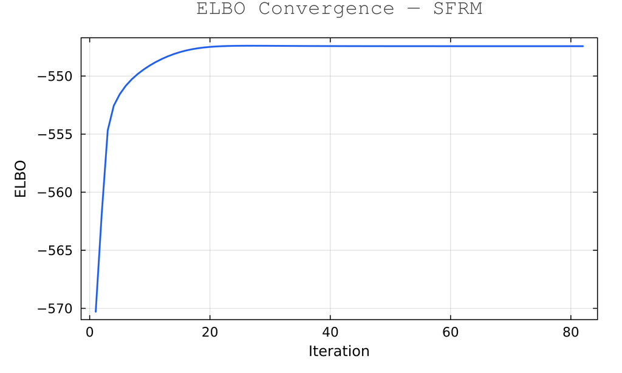

```julia
plot_elbo(res_sfrm; title = "ELBO Convergence — SFRM")
```

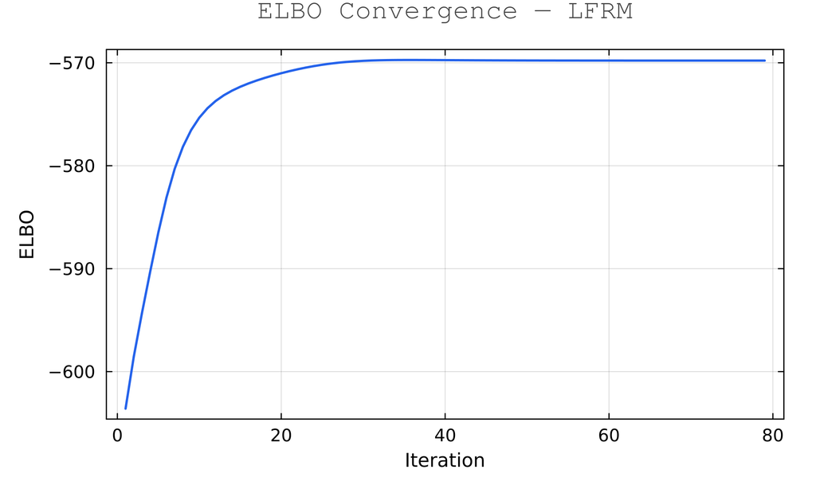

```julia
plot_elbo(res_lfrm; title = "ELBO Convergence — LFRM")
```

A monotonically increasing curve reaching a plateau confirms that CAVI converged.

### 5.2 Cluster Sizes

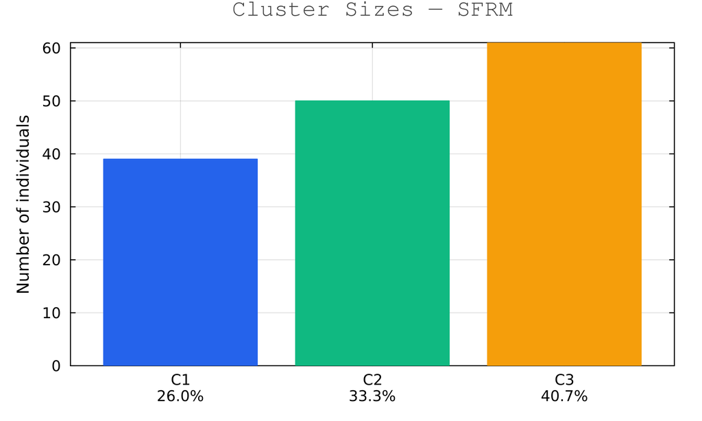

```julia
plot_cluster_sizes(res_sfrm; title = "Cluster Sizes — SFRM")
```

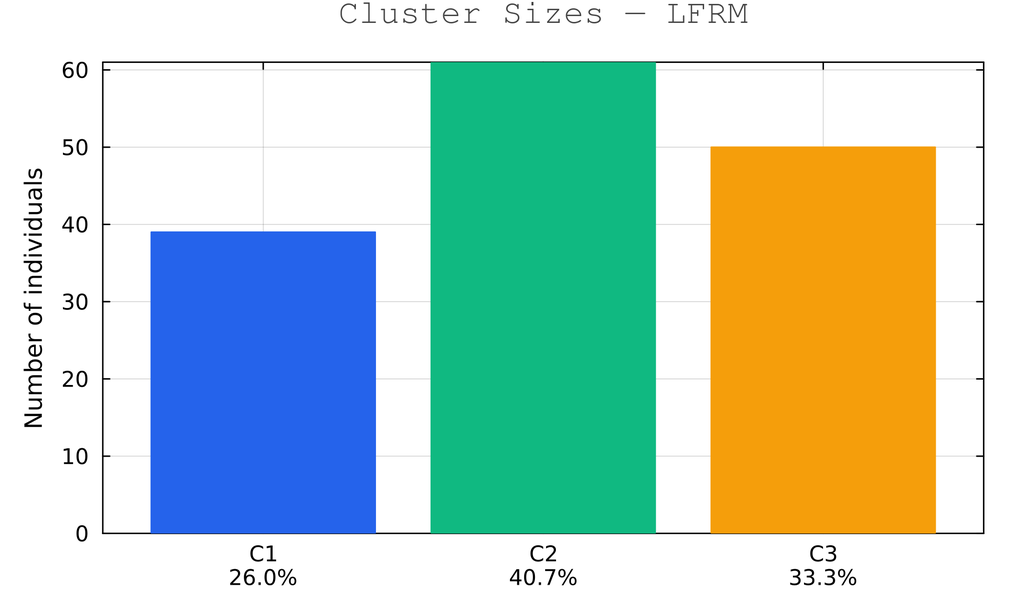

```julia
plot_cluster_sizes(res_lfrm; title = "Cluster Sizes — LFRM")
```

With three balanced species of 50 flowers each, we expect roughly equal cluster sizes. The bar chart immediately shows whether the inferred partition is balanced or dominated by one large group.

### 5.3 Assignment Confidence

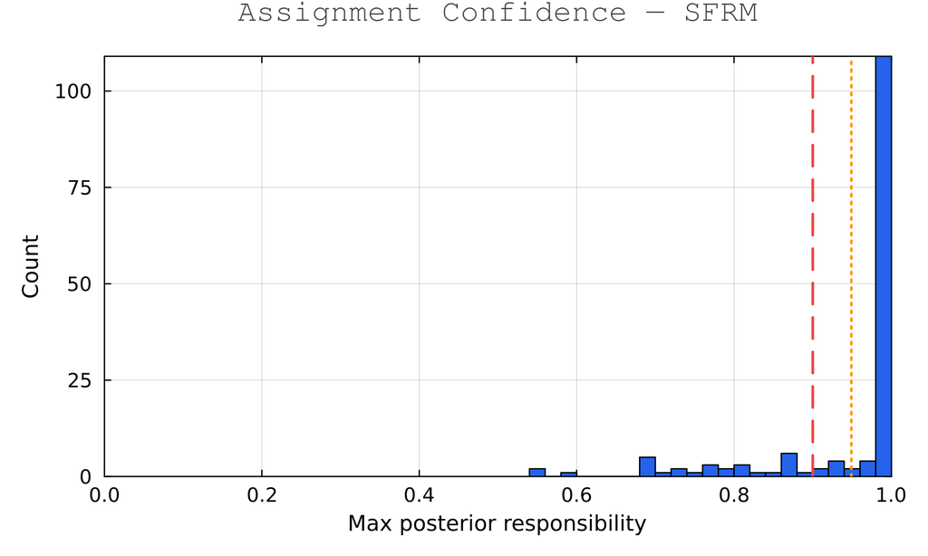

```julia
plot_assignment_confidence(res_sfrm; threshold = 0.9,
                           title = "Assignment Confidence — SFRM")
```

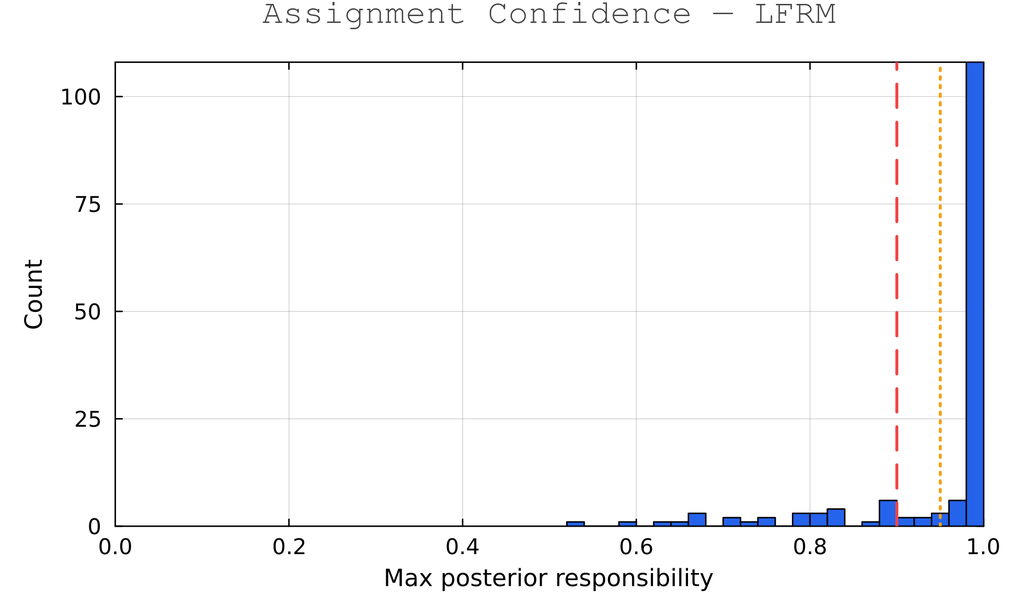

```julia
plot_assignment_confidence(res_lfrm; threshold = 0.9,
                           title = "Assignment Confidence — LFRM")
```

A distribution concentrated near 1 means individuals are assigned crisply to a single cluster. A spread toward $1/K$ signals ambiguity — which is expected for flowers that lie near a species boundary.

### 5.4 Feature Relevance — PIP

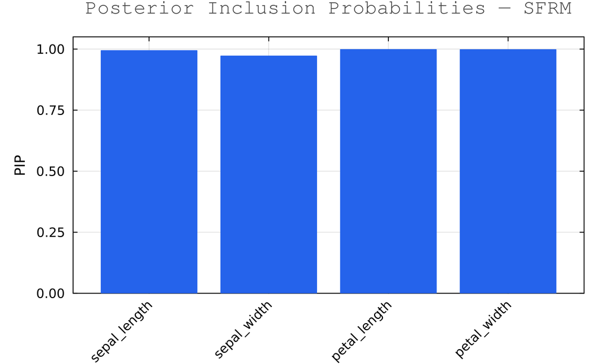

```julia
plot_pips(res_sfrm; feature_names = feature_names,
          title = "Posterior Inclusion Probabilities — SFRM")
```

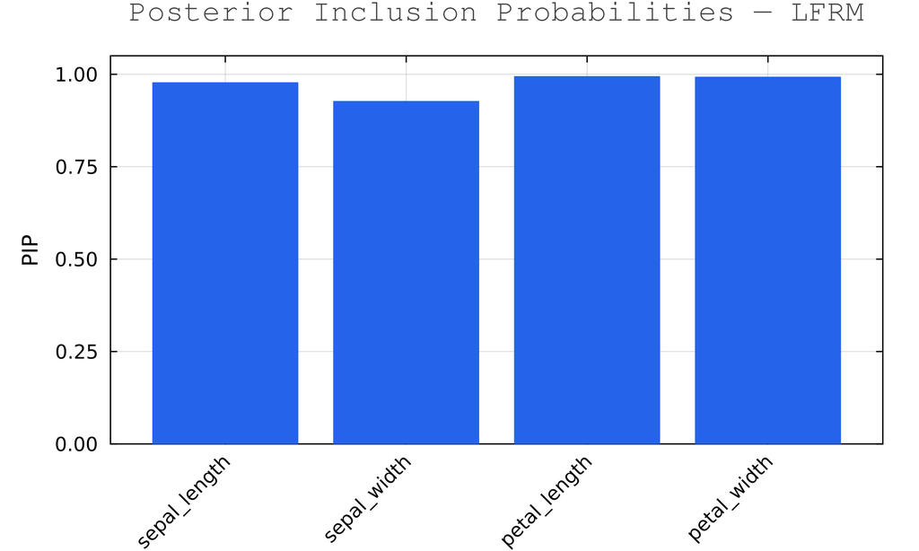

```julia
plot_pips(res_lfrm; feature_names = feature_names,
          title = "Posterior Inclusion Probabilities — LFRM")
```

### 5.5 Feature Relevance — EIG

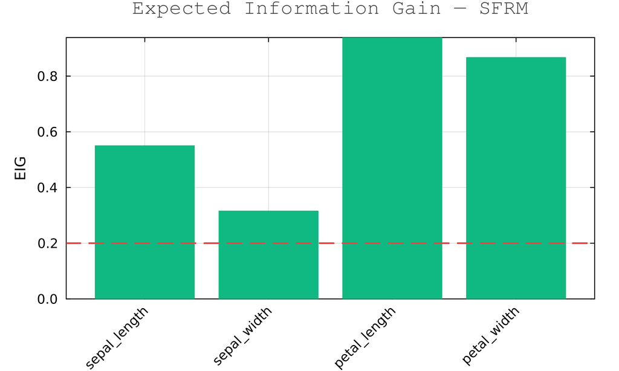

```julia
eig_sfrm = compute_eig(res_sfrm.margins, res_sfrm.w, res_sfrm.pip)
plot_eig(eig_sfrm, 0.20; feature_names = feature_names,
         title = "Expected Information Gain — SFRM")
```

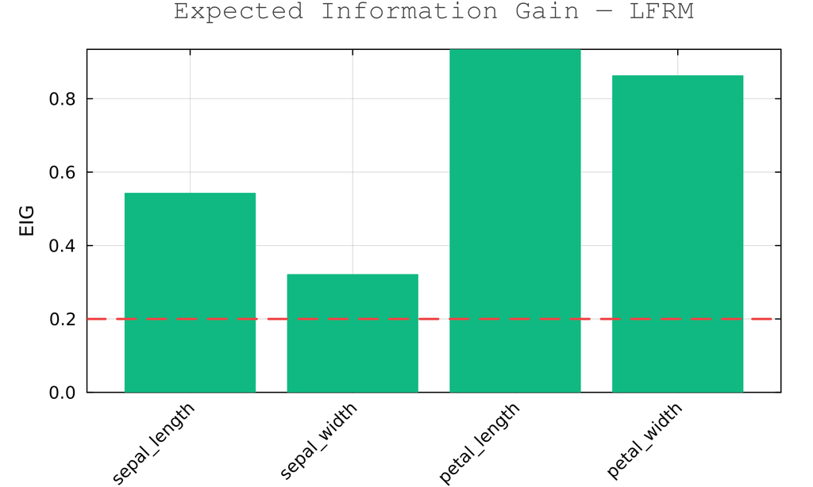

```julia
eig_lfrm = compute_eig(res_lfrm.margins, res_lfrm.w, res_lfrm.pip)
plot_eig(eig_lfrm, 0.20; feature_names = feature_names,
         title = "Expected Information Gain — LFRM")
```

Active features (EIG ≥ 0.20):

```julia
active_sfrm = filter_features(eig_sfrm, 0.20)
active_lfrm = filter_features(eig_lfrm, 0.20)
println("SFRM active: ", feature_names[active_sfrm])
println("LFRM active: ", feature_names[active_lfrm])
```

```
SFRM active: ["sepal_length", "sepal_width", "petal_length", "petal_width"]
LFRM active: ["sepal_length", "sepal_width", "petal_length", "petal_width"]
```

It is well established in the literature that petal measurements are the most discriminative features for separating Iris species; sepal width is often near-noise. The EIG ranking should reflect this directly.

### 5.6 Local PIPs (LFRM)

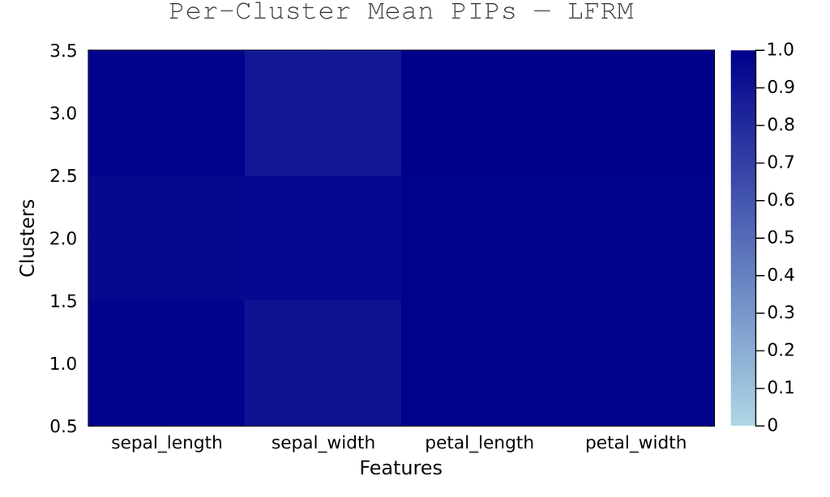

```julia
plot_local_pips(res_lfrm; feature_names = feature_names,
                title = "Per-Cluster Mean PIPs — LFRM")
```

This plot is only meaningful for `LFRM()`. It reveals whether some features are relevant only in a subset of clusters — a finer picture than the global PIP bar chart can provide.

### 5.7 Subtype Feature Profiles

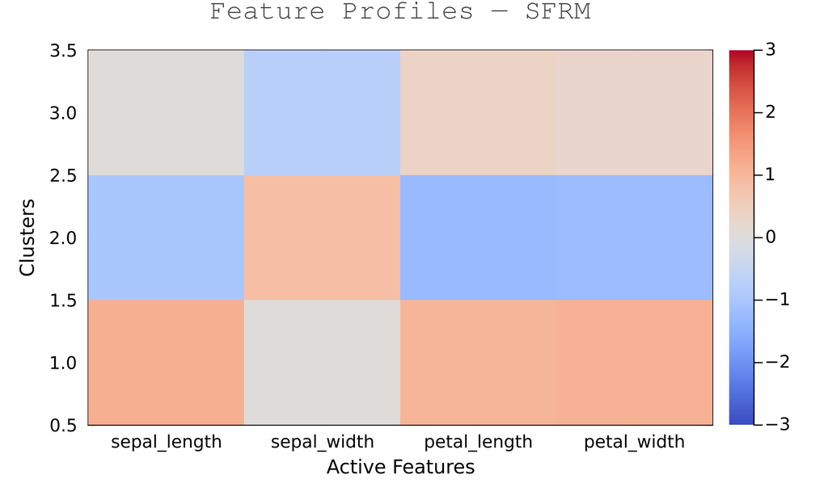

```julia
plot_profiles(res_sfrm, dataset; feature_names = feature_names,
              title = "Feature Profiles — SFRM")
```

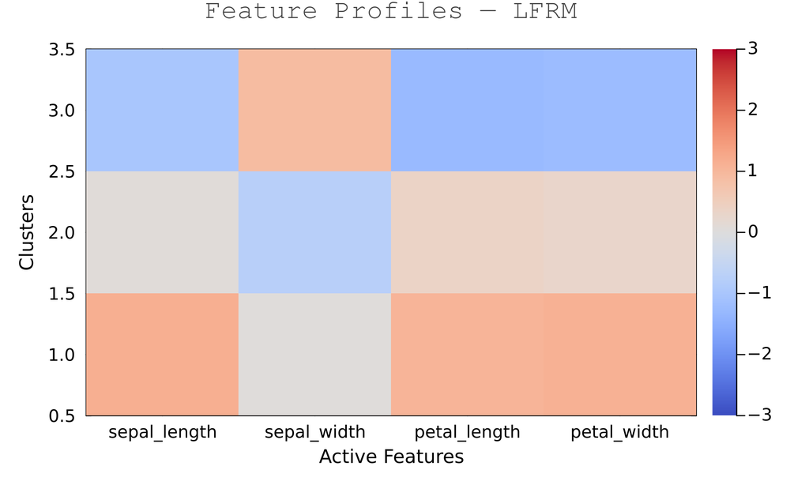

```julia
plot_profiles(res_lfrm, dataset; feature_names = feature_names,
              title = "Feature Profiles — LFRM")
```

Each cell shows the cluster’s expected value as a z-score relative to the population background. Red = above background, blue = below. The three Iris species have well-known morphological signatures: *setosa* has large sepal width and short petals, while *virginica* has long petals; these should appear as distinct rows.

### 5.8 Cluster Assignments in Feature Space

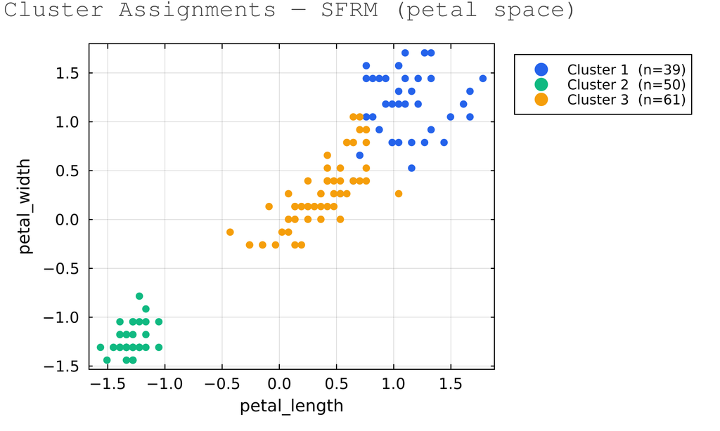

```julia
plot_assignments(res_sfrm, dataset;
                 x_feature = 3, y_feature = 4,
                 feature_names = feature_names,
                 title = "Cluster Assignments — SFRM (petal space)")
```

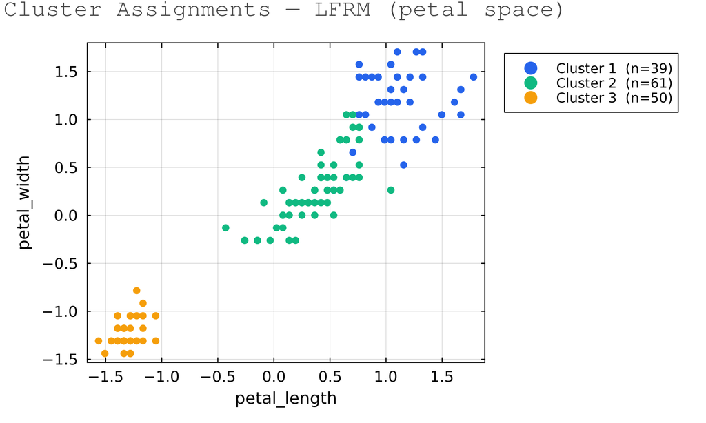

```julia
plot_assignments(res_lfrm, dataset;
                 x_feature = 3, y_feature = 4,
                 feature_names = feature_names,
                 title = "Cluster Assignments — LFRM (petal space)")
```

Petal length and petal width (features 3 and 4) are the most discriminative; the three species form near-separable groups in this 2D projection.